# Heart Disease Classification in R

### Heart disease analysis:

Nous cherchons à évaluer si deux variables (la fréquence cardiaque maximale “max_heart_rate” et le gendre “gender”) sont significativement liées à la présence d’une pathologie cardiaque (“has_heart_rate”).

Le dataset est sur le site https://archive.ics.uci.edu/ml/datasets/Heart+Disease

Ce dataset contient les données de 303 patients inclus dans un essai clinique dans le domaine de la cardiologie.

Packages:

```r
#install.packages("visreg")
#install.packages("vcd")
#install.packages("ggplot2")
```

#### 1. Data preprocessing

```r
heart = read.csv(file = "/home/an/Documents/AnNguyen/AP-HP/heart_disease.csv", head = TRUE, sep=",")
```

```r
str(heart)
```

```
## 'data.frame':    303 obs. of  16 variables:
##  $ age                   : int  63 67 67 37 41 56 62 57 63 53 ...
##  $ gender                : Factor w/ 2 levels "female","male": 2 2 2 2 1 2 1 1 2 2 ...
##  $ chest_pain            : int  1 4 4 3 2 2 4 4 4 4 ...
##  $ resting_blood_pressure: int  145 160 120 130 130 120 140 120 130 140 ...
##  $ serum_cholestoral     : int  233 286 229 250 204 236 268 354 254 203 ...
##  $ fasting_blood_sugar   : int  1 0 0 0 0 0 0 0 0 1 ...
##  $ resting_electro       : int  2 2 2 0 2 0 2 0 2 2 ...
##  $ max_heart_rate        : int  150 108 129 187 172 178 160 163 147 155 ...
##  $ exer_angina           : int  0 1 1 0 0 0 0 1 0 1 ...
##  $ oldpeak               : num  2.3 1.5 2.6 3.5 1.4 0.8 3.6 0.6 1.4 3.1 ...
##  $ slope                 : int  3 2 2 3 1 1 3 1 2 3 ...
##  $ num_vessels_flour     : int  0 3 2 0 0 0 2 0 1 0 ...
##  $ thal                  : int  6 3 7 3 3 3 3 3 7 7 ...
##  $ heart_disease_severity: int  0 2 1 0 0 0 3 0 2 1 ...
##  $ exter_angina          : int  0 1 1 0 0 0 0 1 0 1 ...
##  $ has_heart_disease     : Factor w/ 2 levels "no","yes": 1 2 2 1 1 1 2 1 2 2 ...
```

```r
summary(heart)
```

```
##       age           gender      chest_pain    resting_blood_pressure
##  Min.   :29.00   female: 97   Min.   :1.000   Min.   : 94.0
##  1st Qu.:48.00   male  :206   1st Qu.:3.000   1st Qu.:120.0
##  Median :56.00                Median :3.000   Median :130.0
##  Mean   :54.44                Mean   :3.158   Mean   :131.7
##  3rd Qu.:61.00                3rd Qu.:4.000   3rd Qu.:140.0
##  Max.   :77.00                Max.   :4.000   Max.   :200.0
##
##  serum_cholestoral fasting_blood_sugar resting_electro  max_heart_rate
##  Min.   :126.0     Min.   :0.0000      Min.   :0.0000   Min.   : 71.0
##  1st Qu.:211.0     1st Qu.:0.0000      1st Qu.:0.0000   1st Qu.:133.5
##  Median :241.0     Median :0.0000      Median :1.0000   Median :153.0
##  Mean   :246.7     Mean   :0.1485      Mean   :0.9901   Mean   :149.6
##  3rd Qu.:275.0     3rd Qu.:0.0000      3rd Qu.:2.0000   3rd Qu.:166.0
##  Max.   :564.0     Max.   :1.0000      Max.   :2.0000   Max.   :202.0
##
##   exer_angina        oldpeak         slope       num_vessels_flour
##  Min.   :0.0000   Min.   :0.00   Min.   :1.000   Min.   :0.0000
##  1st Qu.:0.0000   1st Qu.:0.00   1st Qu.:1.000   1st Qu.:0.0000
##  Median :0.0000   Median :0.80   Median :2.000   Median :0.0000
##  Mean   :0.3267   Mean   :1.04   Mean   :1.601   Mean   :0.6722
##  3rd Qu.:1.0000   3rd Qu.:1.60   3rd Qu.:2.000   3rd Qu.:1.0000
##  Max.   :1.0000   Max.   :6.20   Max.   :3.000   Max.   :3.0000
##                                                  NA's   :4
##       thal       heart_disease_severity  exter_angina    has_heart_disease
##  Min.   :3.000   Min.   :0.0000         Min.   :0.0000   no :164
##  1st Qu.:3.000   1st Qu.:0.0000         1st Qu.:0.0000   yes:139
##  Median :3.000   Median :0.0000         Median :0.0000
##  Mean   :4.734   Mean   :0.9373         Mean   :0.3267
##  3rd Qu.:7.000   3rd Qu.:2.0000         3rd Qu.:1.0000
##  Max.   :7.000   Max.   :4.0000         Max.   :1.0000
##  NA's   :2
```

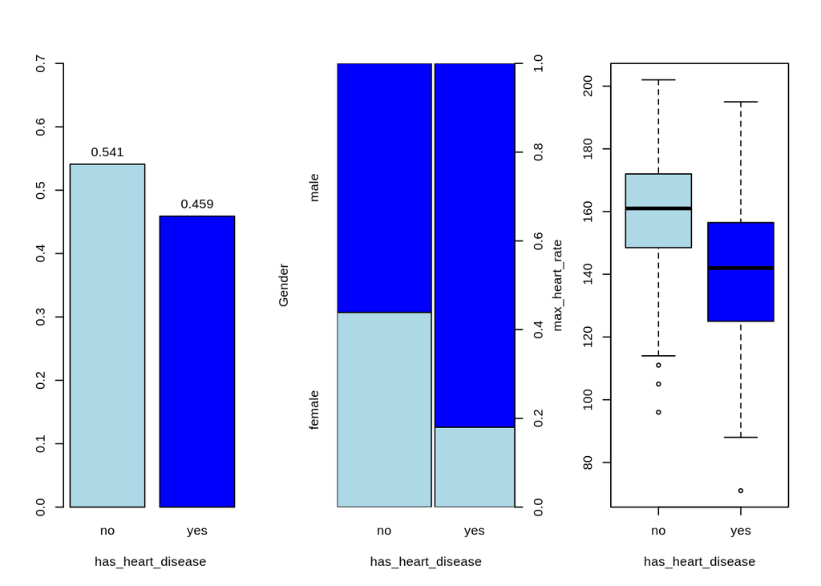

```r
pal <- colorRampPalette(colors = c("lightblue", "blue"))(2)
op <- par(mfrow = c(1, 3))
bp_has <- barplot(round(table(heart$has_heart_disease)/nrow(heart), 3), col = pal, xlab = "has_heart_disease ", ylim = c(0,0.7))
text(bp_has, round(table(heart$has_heart_disease)/nrow(heart),3), round(table(heart$has_heart_disease)/nrow(heart),3), pos=3)
plot(heart$has_heart_disease, heart$gender, col = pal, xlab = "has_heart_disease", ylab = "Gender")
plot(heart$has_heart_disease, heart$max_heart_rate, col = pal, xlab = "has_heart_disease", ylab = "max_heart_rate")
```

```r
par(op)
```

```r
table(is.na(heart))
```

```
##
## FALSE  TRUE
##  4842     6
```

```r
sapply(heart, function(x) sum(is.na(x)))
```

```
##                    age                 gender             chest_pain
##                      0                      0                      0
## resting_blood_pressure      serum_cholestoral    fasting_blood_sugar
##                      0                      0                      0
##        resting_electro         max_heart_rate            exer_angina
##                      0                      0                      0
##                oldpeak                  slope      num_vessels_flour
##                      0                      0                      4
##                   thal heart_disease_severity           exter_angina
##                      2                      0                      0
##      has_heart_disease
##                      0
```

```r
which(is.na(heart$num_vessels_flour))
```

```
## [1] 167 193 288 303
```

```r
which(is.na(heart$thal))
```

```
## [1]  88 267
```

Il y a six valeurs manquants dans ces données. We remove it.

```r
heart <- heart[-c(88, 167, 193, 267, 288, 303),]
```

- le plus jeune a 29 ans, le plus âgé a 77 ans et la moyenne a 54 ans.
- 68.3% de l’homme
- 46% des personnes qui souffrent de la maladie cardiaque

#### 2. Relationship between “gender”, “max_heart_rate”" and “has_heart_disease” using marginal distribution

Nous pouvons vérifier si deux variables catégorielles “gender” and “has_heart_disease” sont indépendantes en utilisant le test d’indépendance du Chi-Squared.

```r
# between gender and has_heart_disease
ygender <- table(heart$has_heart_disease, heart$gender)
chisq.test(ygender)
```

```
##
##  Pearson's Chi-squared test with Yates' continuity correction
##
## data:  ygender
## X-squared = 21.852, df = 1, p-value = 2.946e-06
```

```r
library(vcd)
```

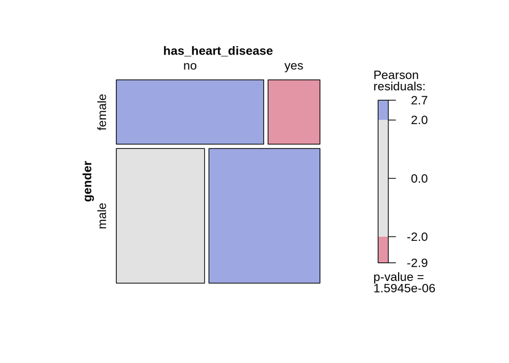

```r
tab <- xtabs(~gender + has_heart_disease, heart)
mosaic(tab,
       shade = TRUE,
       legend = TRUE)
```

Le p-valeur du test de Chi-deux indique que il y a une relation entre le sexe et la présence d’une pathologie cardiaque.

Afin de vérifier la relation entre une variable catégorielle (“has_heart_disease”) et une variable numérique (“max_heart_rate”), nous effectuons généralement un test ANOVA.

```r
# between max_heart_rate and has_heart_disease
ymax_heart_rate <- aov(heart$max_heart_rate ~ heart$has_heart_disease)
summary(ymax_heart_rate)
```

```
##                          Df Sum Sq Mean Sq F value   Pr(>F)
## heart$has_heart_disease   1  27983   27983   64.59 2.24e-14 ***
## Residuals               295 127806     433
## ---
## Signif. codes:  0 '***' 0.001 '**' 0.01 '*' 0.05 '.' 0.1 ' ' 1
```

Le p-valeur a montré que la relation entre “max_heart_rate” et “has_heart_disease” est significative. Donc, nous avons besoin de construire un model pour caractériser ces relations.

#### 3. Relationship between “gender”, “max_heart_rate”" and “has_heart_disease” using joint distribution

#### 3.1 Splitting Dataset into Training set and Test set:

Le “training set” est utilisé pour construire des modèles et pour estimer les paramètres du modèle. Le “test set”" est ensuite utilisé pour estimer le pourcentage de mauvaise classification des modèles.

```r
# install.packages("caTools")
library(caTools)
set.seed(1234)
split <- sample.split(heart$has_heart_disease, SplitRatio = 0.75)
training_set <- subset(heart, split == TRUE)
test_set <- subset(heart, split == FALSE)
```

#### 3.2 Building logistic model

Le modèle de régression logistique est utilisée lorsque la variable dépendante est catégorielle. Ce modèle convient à nos données où la variable dépendante est une variable binaire (“has_heart_disease”).

Afin d’étudier la signification de “gender” et “max_heart_rate”, nous construisons un modèle logistique où la variables à expliquer Y est “has_heart_disease” et les variables explicatives sont: gender + max_heart_rate logit(Y = Yes|Gender, max_heart_rate) = beta_0 + beta_1*gender + beta_2*max_heart_rate

```r
MODEL <- glm(has_heart_disease ~ gender + max_heart_rate, data = training_set, family = binomial)
```

```r
summary(MODEL)
```

```
##
## Call:
## glm(formula = has_heart_disease ~ gender + max_heart_rate, family = binomial,
##     data = training_set)
##
## Deviance Residuals:
##     Min       1Q   Median       3Q      Max
## -2.1828  -0.8770  -0.5142   0.9431   2.1028
##
## Coefficients:
##                 Estimate Std. Error z value Pr(>|z|)
## (Intercept)     5.926984   1.199211   4.942 7.72e-07 ***
## gendermale      1.199206   0.344749   3.478 0.000504 ***
## max_heart_rate -0.046102   0.007939  -5.807 6.37e-09 ***
## ---
## Signif. codes:  0 '***' 0.001 '**' 0.01 '*' 0.05 '.' 0.1 ' ' 1
##
## (Dispersion parameter for binomial family taken to be 1)
##
##     Null deviance: 307.85  on 222  degrees of freedom
## Residual deviance: 250.61  on 220  degrees of freedom
## AIC: 256.61
##
## Number of Fisher Scoring iterations: 4
```

#### 3.3 Interpretation coefficients

- Les variables gender et max_hearte_rate sont significatifs au niveau de 1%.
- Beta_1 = 1.199, donc exp(beta_1) = 3.32>1, ce qui signifie que les hommes étaient 3.32 fois de plus susceptibles de présenter une maladie cardiaque que les femmes.
- Beta_2 = -0.046, donc exp(beta_2) = 0.96 <1, c’est-à-dire que le risque de la présence une maladie cardiaque diminue si le max_heart_rate augmente d’une unité.

On peux voir l’effet du gender et du max_heart_rate sur la présence d’une pathologie cardiaque:

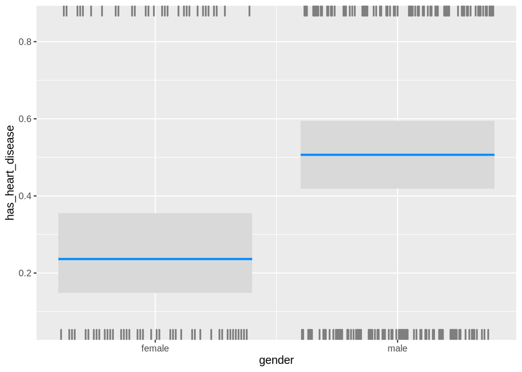

```r
library(visreg)
op <- par(mfrow = c(1,2))
visreg(MODEL, "gender", gg = TRUE, scale="response")
```

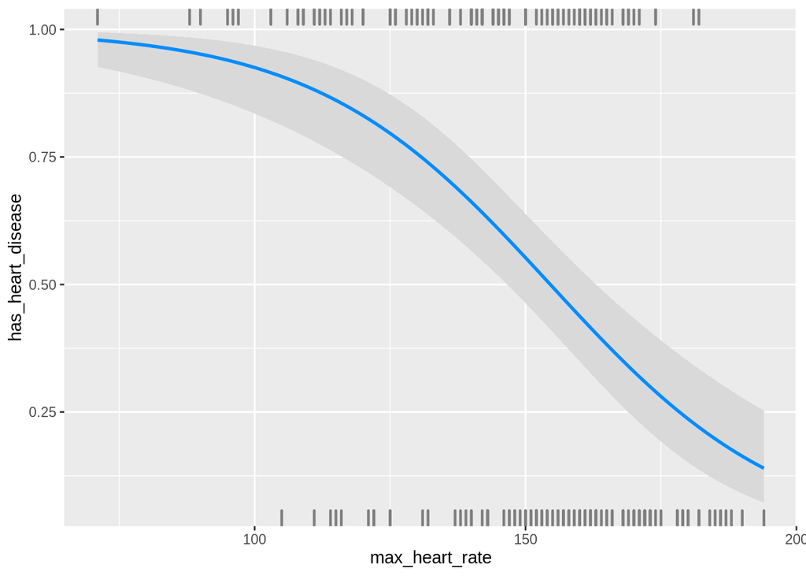

```r
visreg(MODEL, "max_heart_rate", gg = TRUE, scale="response")
```

```r
par(op)
```

#### 3.4 Prediction and ROC curve

```r
pred <- predict(MODEL, type = "response")
```

La courbe ROC en régression logistique est utilisée pour déterminer la meilleure valeur seuil pour prédire si une nouvelle observation est un «YES» ou un «NO» de la présence d’une pathologie cardiaque.

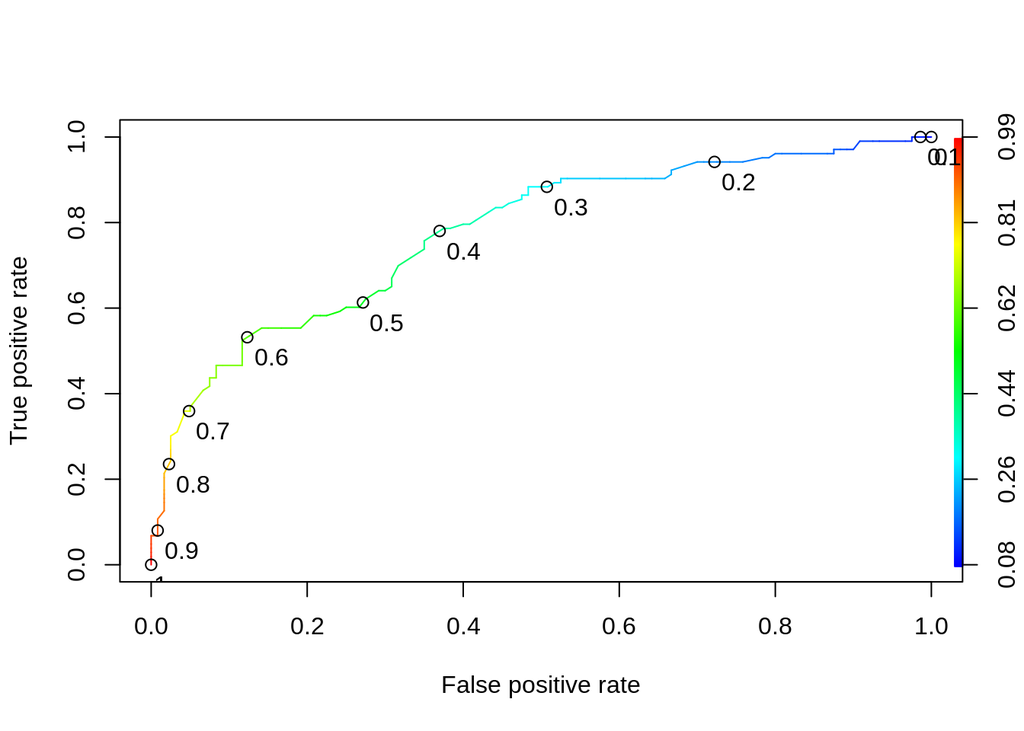

```r
# install.packages("ROCR")
library(ROCR)
ROCpred=prediction(pred, training_set$has_heart_disease)
ROCperf=performance(ROCpred,'tpr','fpr')
plot(ROCperf, colorize=TRUE, print.cutoffs.at=seq(0,1,by=0.1), text.adj=c(-0.2,1.7))
```

```r
auc = as.numeric(performance(ROCpred, 'auc')@y.values)
auc
```

```
## [1] 0.7760922
```

La zone sous la courbe ROC (AUC) = 77,6%.

#### 3.5 Accuracy

La précision de ce modèle sera calculée sur la base de le test set.

```r
predTest=predict(MODEL, newdata = test_set, type = "response")
table(test_set$has_heart_disease, predTest >=0.6) # confused matrix
```

```
##
##       FALSE TRUE
##   no     34    6
##   yes    14   20
```

### 4. Relationship between “gender”, “max_heart_rate”" and “has_heart_disease” using joint distribution (avec toutes les variables)

On intégre toutes les variables de ces données, et puis on enlève une par une des variables qui ne sont pas significartifs, on obtiens ce modèle:

```r
MODELt <- glm(has_heart_disease ~ gender + chest_pain + resting_blood_pressure
             + serum_cholestoral  + max_heart_rate
             + exer_angina
             , data = training_set, family = binomial)
summary(MODELt)
```

```
##
## Call:
## glm(formula = has_heart_disease ~ gender + chest_pain + resting_blood_pressure +
##     serum_cholestoral + max_heart_rate + exer_angina, family = binomial,
##     data = training_set)
##
## Deviance Residuals:
##     Min       1Q   Median       3Q      Max
## -2.5662  -0.7842  -0.2996   0.7532   2.6403
##
## Coefficients:
##                         Estimate Std. Error z value Pr(>|z|)
## (Intercept)            -3.029361   2.226006  -1.361 0.173547
## gendermale              1.673373   0.418675   3.997 6.42e-05 ***
## chest_pain              0.682011   0.193728   3.520 0.000431 ***
## resting_blood_pressure  0.023332   0.010347   2.255 0.024135 *
## serum_cholestoral       0.007524   0.003458   2.175 0.029593 *
## max_heart_rate         -0.037919   0.009226  -4.110 3.96e-05 ***
## exer_angina             0.899116   0.395647   2.273 0.023055 *
## ---
## Signif. codes:  0 '***' 0.001 '**' 0.01 '*' 0.05 '.' 0.1 ' ' 1
##
## (Dispersion parameter for binomial family taken to be 1)
##
##     Null deviance: 307.85  on 222  degrees of freedom
## Residual deviance: 213.56  on 216  degrees of freedom
## AIC: 227.56
##
## Number of Fisher Scoring iterations: 5
```

#### 4.1 Interpretation of coefficients

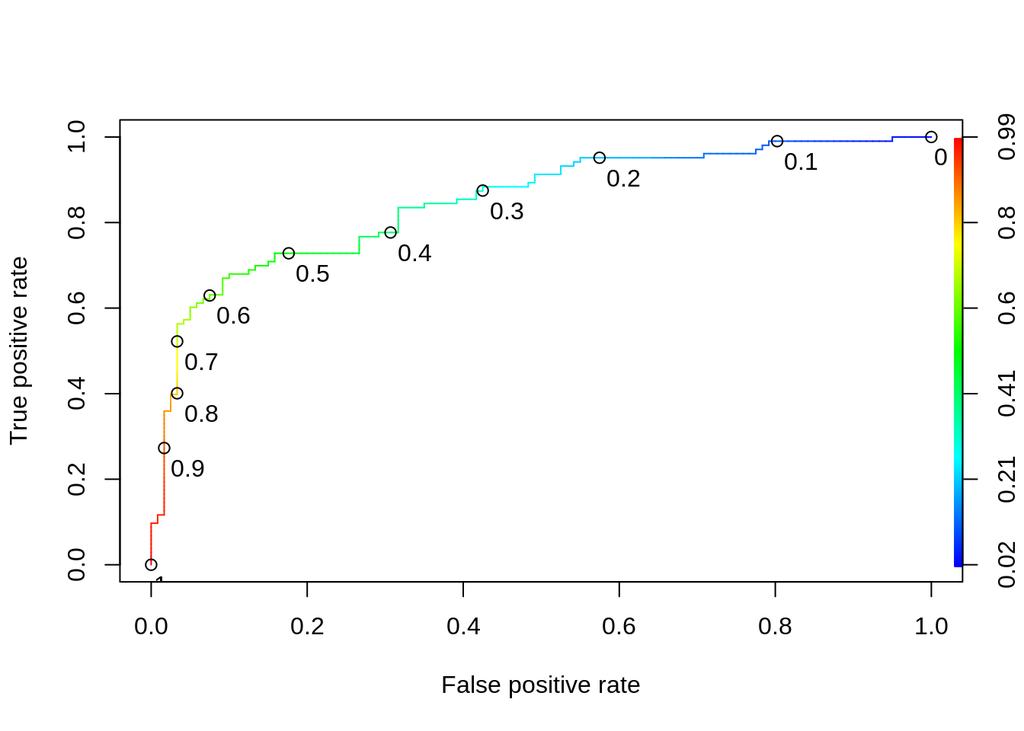

```r
pred <- predict(MODELt, type = "response")
# install.packages("ROCR")
library(ROCR)
ROCpred=prediction(pred, training_set$has_heart_disease)
ROCperf=performance(ROCpred,'tpr','fpr')
plot(ROCperf, colorize=TRUE, print.cutoffs.at=seq(0,1,by=0.1), text.adj=c(-0.2,1.7))
```

```r
auc = as.numeric(performance(ROCpred, 'auc')@y.values)
auc
```

```
## [1] 0.8489482
```

La zone sous la courbe ROC (AUC) = 84,9%.  
En comparant le MODEL et le MODELt, on voie que le MODELt (84.9%) prédit mieux que le MODEL (77.6%).

#### 5. Conlusion:

- On a vérifié les relations entre variables en utilisant la loi marginal et la loi conjoint.
- On a interprété les coefficients pour les modèles logistique.
- On peux choisir un bon modèle pour la prédiction.

#### 6. Machine Learning algorithms: Random forest (Perspective)

En plus du modèle logistique, nous pouvons utiliser un algorithme d’apprentissage automatique pour estimer si une personne souffre d’une maladie cardiaque. L’un de ces algorithmes est la forêt aléatoire (Random Forest)

```r
# install.packages('randomForest')
library(randomForest)
set.seed(1234)
classifier <- randomForest(x = training_set[,-(15:16)],
                          y = training_set$has_heart_disease,
                          ntree = 500)
pred <- predict(classifier, newdata = test_set)
table(test_set$has_heart_disease, pred)
```

```
##      pred
##       no yes
##   no  40   0
##   yes  0  34
```